# Asymptotics

## Asymptotics and LLN

Asymptotics is the term for the behavior of statistics as the sample size (or some other relevant quantity) limits to infinity (or some other relevant number)

### Law of Large Numbers

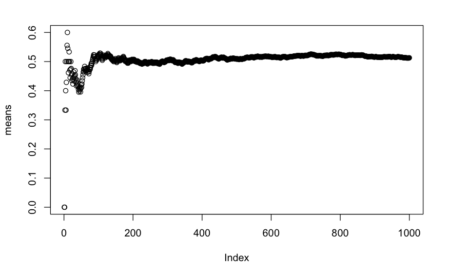

```r
plot(means,grid = T)
```

## Asymptotics and the CLT

The CLT states that the distribution of averages of iid variables (properly normalized) becomes that of a standard normal as **the sample size** increases.

Die roles m = 3.5, Var = 2.92, SE = sqrt(var/n) = 1.71/sqrt(n) lets roll n dice, take their mean, subtract off 3.5 (center around zero) and divide by 1.71/sqrt(n)

Coin CLT E = p, Var = p(1-p), SE = sqrt(p(1-p)/n) Again, take sample mean, subtract mean, and divide by SE

If the coin is not biased, convergence to normal is fast, but for p = 0.9, you need a larger sample

## Asymptotics and confidence intervals

Xhat +- 2 SE(sigma/sqrt(n)) is called a 95% interval for m

```r
library(UsingR)
data(father.son)

x <- father.son$sheight
(mean(x) + c(-1,1)*qnorm(0.975)*sd(x)/sqrt(length(x)))/12
```

```
[1] 5.709670 5.737674
```

Your campaign advisor told you that in a random sample of 100 likely voters, 56 intent to vote for you. - Can you relax? Do you have this race in the bag? - Without access to a computer or calculator, how precise is this estimate?

1/sqrt(100) = 0.1 - back of the envelope calculation gives an approximate 95% interval of (0.46, 0.66) - Not enough for you to relax, better go do more campaigning!

Rough guidelines, 100 for 1 decimal place, 10_000 for 2, 1_000_000 for 3.

```r
round(1/sqrt(10^(1:6)), 3)
```

```
[1] 0.316 0.100 0.032 0.010 0.003 0.001
```

```r
0.56 + c(-1,1) * qnorm(0.975)*sqrt(0.56 * 0.44/100)
```

```
[1] 0.4627099 0.6572901
```

```r
binom.test(56, 100)$conf.int
```

```
[1] 0.4571875 0.6591640
attr(,"conf.level")
[1] 0.95
```

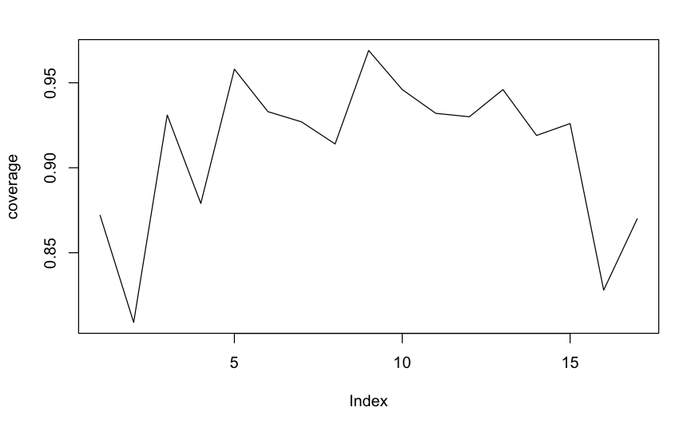

```r
n <- 20
pvals <- seq(0.1, 0.9, by = 0.05)
nosim <- 1000

#sample size 20, 1000 draws, different proba
coverage <- sapply(pvals, function(p){
  phats <- rbinom(nosim, prob = p, size =n )/n
  il <- phats - qnorm(0.975)*sqrt(phats*(1-phats)/n)
  ul <- phats + qnorm(0.975)*sqrt(phats*(1-phats)/n)
  mean(il < p & ul > p)
})

plot(coverage, type='line')
```

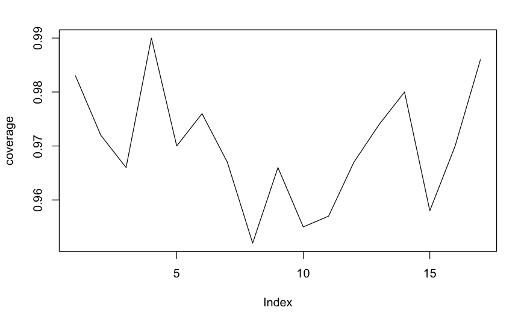

```r
n <- 20
pvals <- seq(0.1, 0.9, by = 0.05)
nosim <- 1000

#Adding 2 successes and 2 failures
coverage <- sapply(pvals, function(p){
  phats <- (2 + rbinom(nosim, prob = p, size =n ))/(n + 4)
  il <- phats - qnorm(0.975)*sqrt(phats*(1-phats)/n)
  ul <- phats + qnorm(0.975)*sqrt(phats*(1-phats)/n)
  mean(il < p & ul > p)
})

plot(coverage, type='line')
```

Why is the CLT Wald Intervals not so good at small probabilities? Remember that for smaller probas, the CLT needs bigger sample to work. Repeat with 100 instead of 20.

Quick fix, form the interval with X+2/n+4 -> **Agresti/Couli interval - add two successes and failures**

### Poisson interval

A nuclear pump failed 5 times out of 94.32 days, give a 95% confidence interval for the failure rate. X ~ Poisson(lambda t)

```r
x <- 5
t <- 94.32
lambda <- x/t
round(lambda + c(-1, 1)*qnorm(0.975)*sqrt(lambda/t), 3)
```

```
[1] 0.007 0.099
```

```r
# A bit conservative
poisson.test(x, T = 94.32)$conf
```

```
[1] 0.01721254 0.12371005
attr(,"conf.level")
[1] 0.95
```

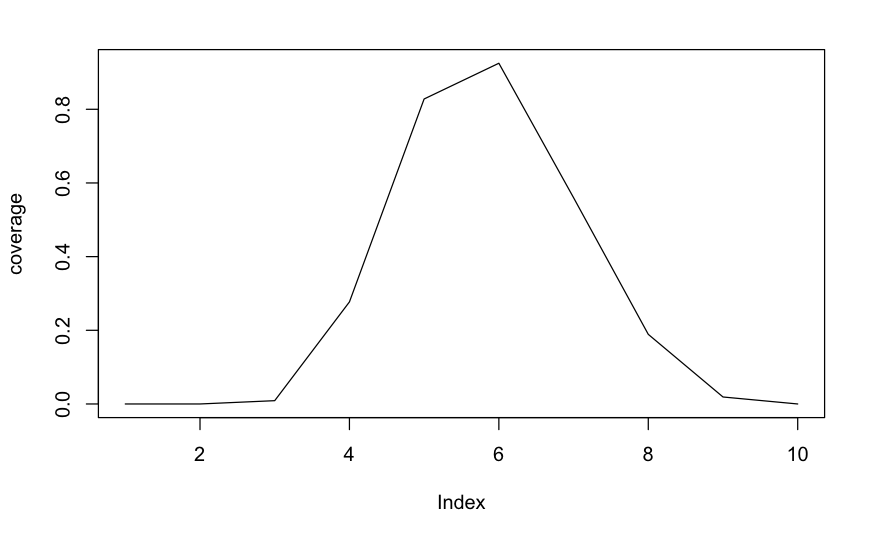

```r
lambdavals <- seq(0.005, 0.1, by = 0.01)
nosim <- 1000
t <- 1000

coverage <- sapply(lambdavals, function(p){
  lhats <- rpois(nosim, lambda = lambda*t)/t
  il <- lhats - qnorm(0.975)*sqrt(lhats/t)
  ul <- lhats + qnorm(0.975)*sqrt(lhats/t)
  mean(il < p & ul > p)
})

plot(coverage, type='line')
```